# Lab 3

Muhamad Imran Bin Maszeri

9/25/2020

Good analysis and code, thanks for help!

Reading and cleaning data

```r
library(readxl)
library(ggplot2)
library(tidyverse)
library(dplyr)
dat <- readxl::read_xls('GSS.xls')
newdat <- dat %>%
  rename(year=`Gss year for this respondent`,
         marital=`Marital status`,
         educ=`Highest year of school completed`,
         sex=`Respondents sex`,
         partyid=`Political party affiliation`,
         happy=`General happiness`,
         ballot=`Ballot used for interview`,
         id=`Respondent id number`,
         conpress=`Confidence in press`,
         bills=`Income alone is enough`,
         qlife=`R's quality of life`) %>%
  filter(!educ %in% c("No answer", "Don't know")) %>%
  filter(!marital %in% c("No answer")) %>%
  filter(!partyid %in% c("No answer", "Don't know"))

str(newdat)
```

```
## tibble [64,239 x 11] (S3: tbl_df/tbl/data.frame)
##  $ year    : num [1:64239] 1972 1972 1972 1972 1972 ...
##  $ ballot  : chr [1:64239] "Not applicable" "Not applicable" "Not applicable" "Not applicable" ...
##  $ bills   : chr [1:64239] "Not applicable" "Not applicable" "Not applicable" "Not applicable" ...
##  $ conpress: chr [1:64239] "Not applicable" "Not applicable" "Not applicable" "Not applicable" ...
##  $ happy   : chr [1:64239] "Not too happy" "Not too happy" "Pretty happy" "Not too happy" ...
##  $ partyid : chr [1:64239] "Ind,near dem" "Not str democrat" "Independent" "Not str democrat" ...
##  $ sex     : chr [1:64239] "Female" "Male" "Female" "Female" ...
##  $ educ    : chr [1:64239] "16" "10" "12" "17" ...
##  $ marital : chr [1:64239] "Never married" "Married" "Married" "Married" ...
##  $ id      : num [1:64239] 1 2 3 4 5 6 7 8 9 10 ...
##  $ qlife   : chr [1:64239] "Not applicable" "Not applicable" "Not applicable" "Not applicable" ...
```

1. Find the average years of education for the respondents with each political party affiliation. Arrange your output in a meaningful order and print. Describe any patterns you find.

```r
edparty <- newdat %>%
  mutate(educ=as.numeric(educ)) %>%
  select(educ, partyid) %>%
  group_by(partyid) %>%
  drop_na() %>%
  summarise(mean_edu=mean(educ), .groups='drop') %>%
  arrange(desc(mean_edu))

edparty
```

```
## # A tibble: 8 x 2
##   partyid            mean_edu
##   <chr>                 <dbl>
## 1 Strong republican      13.4
## 2 Other party            13.4
## 3 Ind,near rep           13.3
## 4 Not str republican     13.3
## 5 Ind,near dem           13.2
## 6 Not str democrat       12.6
## 7 Strong democrat        12.5
## 8 Independent            12.3
```

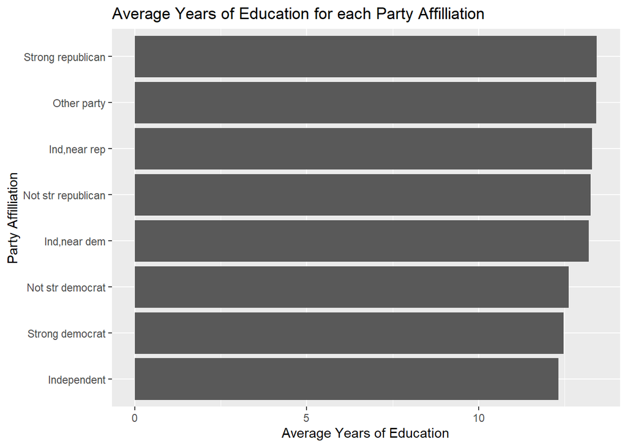

```r
ggplot(edparty, aes(x=reorder(partyid,mean_edu), weight=mean_edu)) + geom_bar() + coord_flip() + labs(title="Average Years of Education for each Party Affilliation", x="Party Affilliation", y="Average Years of Education")
```

Answer: The average years of education are highest for two party affiliation; Strong Republican and Other Party, with an average of 13.4. The least average years of education are Independent, with an average of 12.3

2. Create a single data frame containing records for the better educated respondents in each political party affiliation. A “better educated” respondent is someone who has strictly more years of education than the median in the same party affiliation. Print the structure of the data frame.

```r
df1 <- newdat %>%
  mutate(educ=as.numeric(educ)) %>%
  group_by(partyid) %>%
  mutate(median_educ=median(educ, na.rm = TRUE)) %>%
  filter(educ>median_educ) %>%
  ungroup()

str(df1)
```

```
## tibble [27,670 x 12] (S3: tbl_df/tbl/data.frame)
##  $ year       : num [1:27670] 1972 1972 1972 1972 1972 ...
##  $ ballot     : chr [1:27670] "Not applicable" "Not applicable" "Not applicable" "Not applicable" ...
##  $ bills      : chr [1:27670] "Not applicable" "Not applicable" "Not applicable" "Not applicable" ...
##  $ conpress   : chr [1:27670] "Not applicable" "Not applicable" "Not applicable" "Not applicable" ...
##  $ happy      : chr [1:27670] "Not too happy" "Not too happy" "Pretty happy" "Not too happy" ...
##  $ partyid    : chr [1:27670] "Ind,near dem" "Not str democrat" "Ind,near dem" "Ind,near dem" ...
##  $ sex        : chr [1:27670] "Female" "Female" "Male" "Male" ...
##  $ educ       : num [1:27670] 16 17 14 16 13 14 14 17 14 16 ...
##  $ marital    : chr [1:27670] "Never married" "Married" "Never married" "Never married" ...
##  $ id         : num [1:27670] 1 4 6 8 11 16 17 19 20 25 ...
##  $ qlife      : chr [1:27670] "Not applicable" "Not applicable" "Not applicable" "Not applicable" ...
##  $ median_educ: num [1:27670] 13 12 13 13 12 12 13 13 13 13 ...
```

For each of the investigation below, create at least one numerical summary and one appropriate visualization. Write a paragraph to describe your findings and the variables you used.

3. How is the happiness of a respondent related to his/her marriage status? Define that a person is happy if the response to question is “Very happy” or “Pretty happy”.

```r
hap <- newdat %>%
  filter(happy %in% c("Pretty happy", "Very happy")) %>%
  select(happy, marital) %>%
  group_by(marital) %>%
  summarise(nHappy=n()) %>%
  arrange(nHappy)

hap
```

```
## # A tibble: 5 x 2
##   marital       nHappy
##   <chr>          <int>
## 1 Separated       1473
## 2 Widowed         4615
## 3 Divorced        6129
## 4 Never married  10606
## 5 Married        29142
```

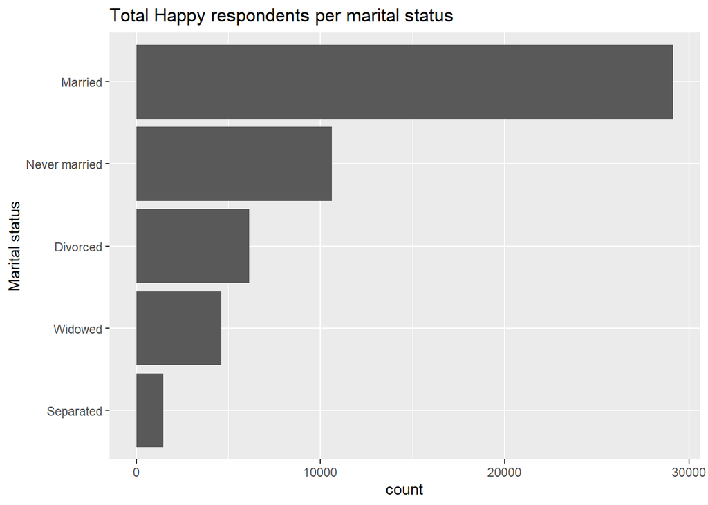

```r
ggplot(hap, aes(x=reorder(marital,nHappy), weight=nHappy)) + geom_bar() + coord_flip() + labs(title="Total Happy respondents per marital status", x="Marital status")
```

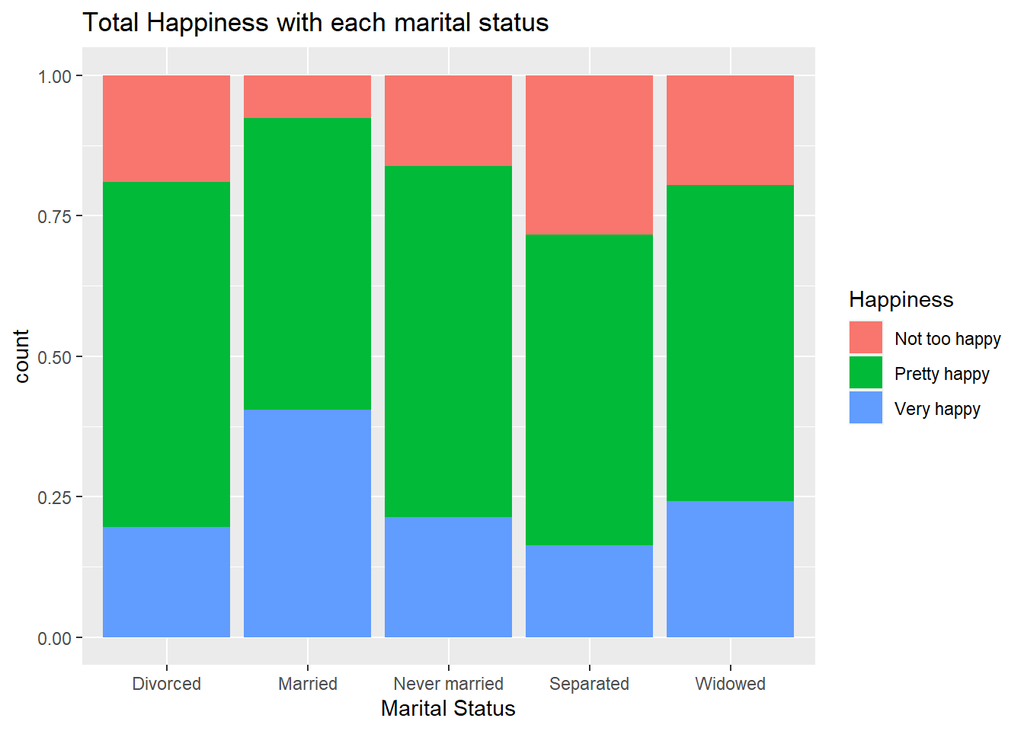

```r
newdat %>%
  select(happy, marital) %>%
  filter(happy %in% c("Not too happy", "Pretty happy", "Very happy")) %>%
  drop_na() %>%
  ggplot(aes(x=marital, fill=happy)) + geom_bar(position='fill') + labs(title="Total Happiness with each marital status", x="Marital Status", fill="Happiness")
```

Answer: Using Very Happy and Pretty Happy, it can be found that Married respondents are the most happiest, with separated the lowest that is happy.Using all the happiness per marital status, it can be seen that married respondents have a much higher rate of “very happy” respondents compared to other marital status. Separated respondents have a much higher rate of “Not too happy” compared to other marital status.

4. Does party affiliation affect the relationship you found in the last question?

```r
newdat %>%
  select(happy, marital, partyid) %>%
  filter(happy %in% c("Pretty happy", "Very happy")) %>%
  drop_na() %>%
  group_by(marital, partyid) %>%
  summarise(nHappy=n()) %>%
  arrange(desc(nHappy))
```

```
## # A tibble: 40 x 3
## # Groups:   marital [5]
##    marital       partyid            nHappy
##    <chr>         <chr>               <int>
##  1 Married       Not str democrat     5961
##  2 Married       Not str republican   5250
##  3 Married       Strong democrat      4141
##  4 Married       Independent          3919
##  5 Married       Strong republican    3402
##  6 Married       Ind,near dem         3196
##  7 Married       Ind,near rep         2823
##  8 Never married Not str democrat     2254
##  9 Never married Independent          1815
## 10 Never married Ind,near dem         1669
## # ... with 30 more rows
```

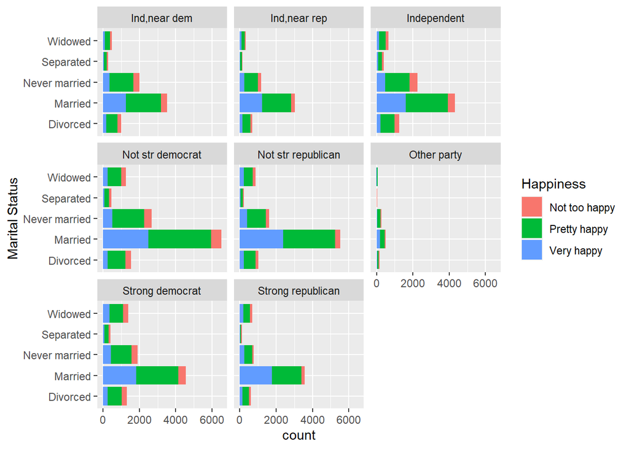

```r
newdat %>%
  select(happy, marital, partyid) %>%
  filter(happy %in% c("Not too happy", "Pretty happy", "Very happy")) %>%
  drop_na() %>%
  ggplot(aes(x=marital, fill=happy)) + geom_bar(position='stack') + labs(fill="Happiness", x="Marital Status") + facet_wrap(~partyid) + coord_flip()
```

Answer: All of the party affiliations have a very high happiness for married respondents. Happy, Married respondents are the highest and have an affilliation for not strong democrat, followed closely by not strong republicans. However, Not too happy respondents are much more higher in not strong democrat compared to not strong republican. Many unhappy married respondents are affilliated more towards not strong democrat rather than not strong republican or any other party affiliation

5. How is marrital status related to the education of a respondent? What are possible reasons accounting for the patterns you see?

```r
newdat %>%
  select(marital, educ) %>%
  mutate(educ=as.numeric(educ)) %>%
  group_by(marital) %>%
  drop_na() %>%
  summarise(mean_edu=mean(educ), med_edu=median(educ), .groups='drop')
```

```
## # A tibble: 5 x 3
##   marital       mean_edu med_edu
##   <chr>            <dbl>   <dbl>
## 1 Divorced          13.1      13
## 2 Married           13.0      12
## 3 Never married     13.4      13
## 4 Separated         11.9      12
## 5 Widowed           11.2      12
```

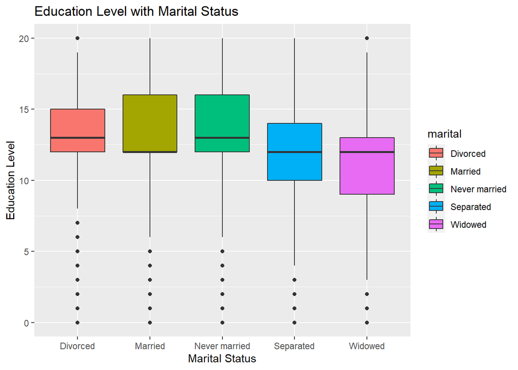

```r
newdat %>%
  select(marital, educ) %>%
  mutate(educ=as.numeric(educ)) %>%
  drop_na() %>%
  ggplot(aes(marital, educ, fill=marital)) + geom_boxplot() + labs(title="Education Level with Marital Status", x="Marital Status", y="Education Level")
```